# Dhairya Kothari

#### Why do we talk about generalization with regard to learning problems?

Generalization with regards to learning problems is talked about a lot due to the fact that, when we want to train a model, we dont want the model to just perform well with the training data. We want it to perform well in as many cases as possible.

#### What is overfitting in learning?

Overfitting means learning the regression on the training data so much that it perfectly (or near perfectly) fits the data given to train, takes the shape and form of that so much that it cannot predict a new testing data without increase in variance.

#### How can we avoid overfitting for this regression problem? Implement this in your Jupyter notebook and show how overfitting is reduced with your method. Note: Your method should automatically reduce overfitting. Hint: Regularization.

We can avoid overfitting by regularization techniques such as: Ridge, Lasso, Elastic-Net, etc. Here we use Elastic-Net regularization to fight the overfitting. Its effect on various degree polynomials is seen below.

```python
import matplotlib
%matplotlib inline
import warnings
warnings.filterwarnings('ignore')

import numpy as np
import matplotlib.pyplot as matplot

from sklearn.linear_model import LinearRegression
from sklearn.linear_model import ElasticNet
from sklearn.preprocessing import PolynomialFeatures
from sklearn.pipeline import make_pipeline
```

```python
def f(x):
    return x * np.cos(x)

# generate points used to plot
x_plot = np.linspace(0, 15, 100)
# generate points and keep a subset of them
x = np.linspace(0, 15, 100)
rng = np.random.RandomState(0)
rng.shuffle(x)
x = np.sort(x[:90])
y = f(x)
# create matrix versions of these arrays
X = x[:, np.newaxis]
X_plot = x_plot[:, np.newaxis]
```

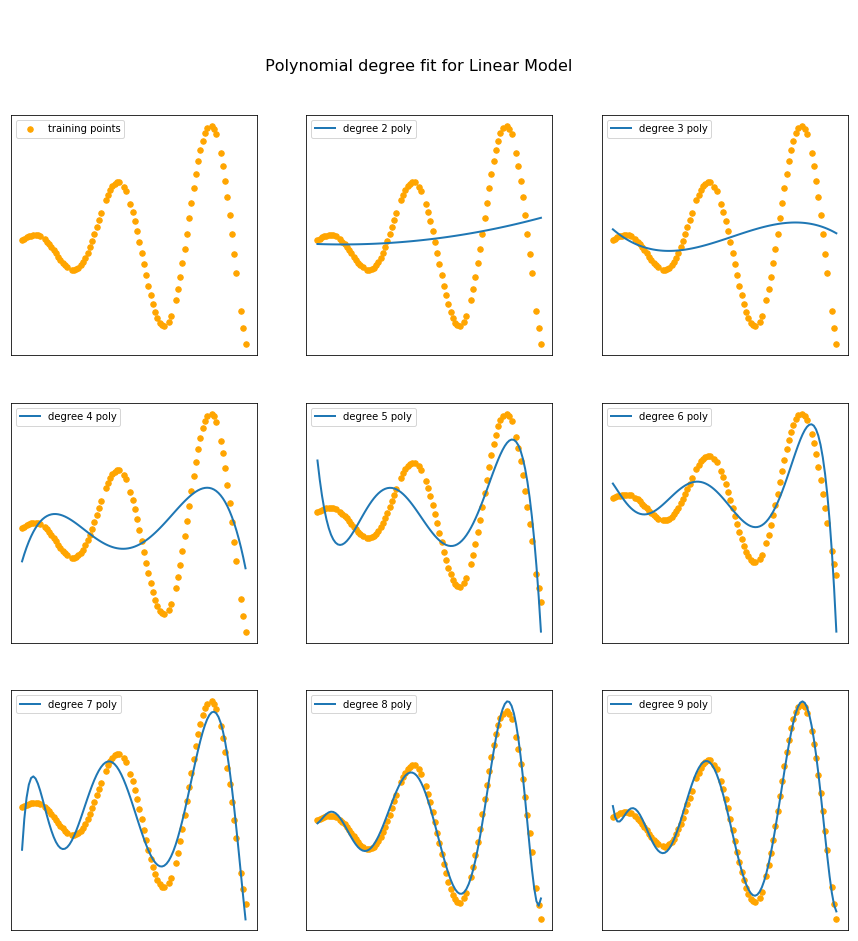

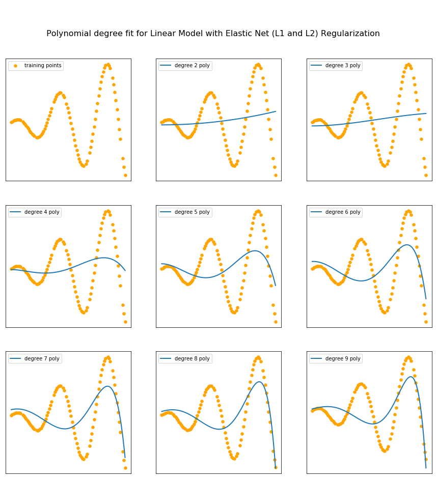

```python
matplot.subplots(3,3, figsize=(15,15))
for i, degree in enumerate([0,2,3,4,5,6,7,8,9]):
    if i==0:
        l1 = matplot.subplot(3, 3, 1)
        l1.scatter(x, y, color='orange', s=30, marker='o', label="training points")
        l1.set_xticks(())
        l1.set_yticks(())
        l1.legend()
    else:
        model = make_pipeline(PolynomialFeatures(degree), LinearRegression())
        model.fit(X, y)
        y_plot = model.predict(X_plot)
        l1 = matplot.subplot(3, 3, i + 1)
        l1.scatter(x, y, color='orange', s=30, marker='o')
        l1.plot(x_plot, y_plot, linewidth=2, label="degree %d poly" % degree)
        l1.set_xticks(())
        l1.set_yticks(())
        l1.legend()
matplot.suptitle('\n \n \n Polynomial degree fit for Linear Model', fontsize=16)
matplot.show()

####### ----------------------------------------------------------------------

matplot.subplots(3,3, figsize=(15,15))
for i, degree in enumerate([0,2,3,4,5,6,7,8,9]):
    if i==0:
        l1 = matplot.subplot(3, 3, 1)
        l1.scatter(x, y, color='orange', s=30, marker='o', label="training points")
        l1.set_xticks(())
        l1.set_yticks(())
        l1.legend()
    else:
        model = make_pipeline(PolynomialFeatures(degree), ElasticNet())
        model.fit(X, y)
        y_plot = model.predict(X_plot)
        l1 = matplot.subplot(3, 3, i + 1)
        l1.scatter(x, y, color='orange', s=30, marker='o')
        l1.plot(x_plot, y_plot, linewidth=2, label="degree %d poly" % degree)
        l1.set_xticks(())
        l1.set_yticks(())
        l1.legend()
matplot.suptitle('\n \n \n Polynomial degree fit for Linear Model with Elastic-Net (L1 and L2) Regularization', fontsize=16)
matplot.show()
```

### Conclusion

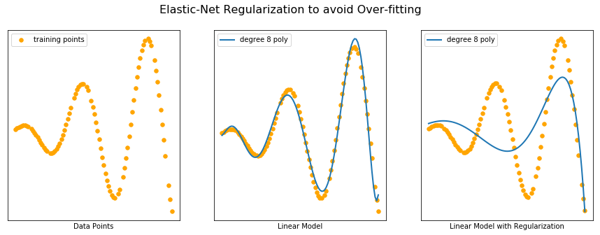

```python
matplot.subplots(1,3, figsize=(15,5))
l12 = matplot.subplot(1, 3, 1)
l12.scatter(x, y, color='orange', s=30, marker='o', label="training points")
l12.set_xticks(())
l12.set_yticks(())
l12.set_xlabel('Data Points')
l12.legend()
#-----------------------
model = make_pipeline(PolynomialFeatures(8), LinearRegression())
model.fit(X, y)
y_plot = model.predict(X_plot)
l12 = matplot.subplot(1, 3, 2)
l12.scatter(x, y, color='orange', s=30, marker='o')
l12.plot(x_plot, y_plot, linewidth=2, label="degree 8 poly")
l12.set_xticks(())
l12.set_yticks(())
l12.set_xlabel('Linear Model')
l12.legend()
#-----------------------
model = make_pipeline(PolynomialFeatures(8), ElasticNet())
model.fit(X, y)
y_plot = model.predict(X_plot)
l12 = matplot.subplot(1, 3, 3)
l12.scatter(x, y, color='orange', s=30, marker='o')
l12.plot(x_plot, y_plot, linewidth=2, label="degree 8 poly")
l12.set_xticks(())
l12.set_yticks(())
l12.set_xlabel('Linear Model with Regularization')
l12.legend()
#-----------------------
matplot.suptitle('Elastic-Net Regularization to avoid Over-fitting', fontsize=16)
matplot.show()
```

References:  
Scikit Learn Documentation http://scikit-learn.org/stable/modules/linear_model.html